# Market Basket Analysis

Katherine Piatti

3/19/2021

# INTRODUCTION

Blackwell Electronics’ board of directors is considering acquiring Electronidex, a start-up electronics online retailer. The board of directors has asked us to help them better understand the clientele that Electronidex currently is serving and if it would be an optimal partnership. Some questions to consider:

- Are there any interesting patterns or item relationships within Electronidex’s transactions?
- Would Blackwell benefit from selling any of Electronidex’s items?
- In your opinion, should Blackwell acquire Electronidex?
- If Blackwell does acquire Electronidex, do you have any recommendations for Blackwell? (Ex: cross-selling items, sale promotions, should they remove items, etc.)

## Business Need

They need our help to identify purchasing patterns that will provide insight into Electronidex’s clientele.

## Objectives

- Conduct a *market basket analysis* to discover any interesting relationships (or associations) between customers’ transactions and the item(s) they purchased.

## Load Packages

```r
#load standard pkgs
library(tidyverse)
library(here)
library(janitor)
library(skimr)
library(ggplot2)
library(reader)
library(kableExtra)

#load pkgs for market basket analysis
library(arules)
library(arulesViz)
```

## Import Data

```r
#read in transnational data using read.transactions() from arules pkg
df_transactions <- read.transactions(
  here('Data', 'ElectronidexTransactions2017.csv'),
  format = 'basket',
  sep = ',',
  rm.duplicates = TRUE)
```

```
## distribution of transactions with duplicates:
## items
##   1   2
## 191  10
```

```r
# verify import
(df_transactions)
```

```
## transactions in sparse format with
##  9835 transactions (rows) and
##  125 items (columns)
```

## Metadata

- Dataset contains transaction data from 30 days of Electronidex’s online transactions in 2017.
- Data is represented in sparse matix with 9,835 rows (transactions) and 125 columns (items.).
- Also sent PDF list with 125 items divided into 17 product categories (e.g. laptops, desktops, monitors, computer mice)

# DATA EXPLORATION

## Overview

```r
# return summary info about the dataset
summary(df_transactions)
```

```
## transactions as itemMatrix in sparse format with
##  9835 rows (elements/itemsets/transactions) and
##  125 columns (items) and a density of 0.03506172
##
## most frequent items:
##                     iMac                HP Laptop CYBERPOWER Gamer Desktop
##                     2519                     1909                     1809
##            Apple Earpods        Apple MacBook Air                  (Other)
##                     1715                     1530                    33622
##
## element (itemset/transaction) length distribution:
## sizes
##    0    1    2    3    4    5    6    7    8    9   10   11   12   13   14   15
##    2 2163 1647 1294 1021  856  646  540  439  353  247  171  119   77   72   56
##   16   17   18   19   20   21   22   23   25   26   27   29   30
##   41   26   20   10   10   10    5    3    1    1    3    1    1
##
##    Min. 1st Qu.  Median    Mean 3rd Qu.    Max.
##   0.000   2.000   3.000   4.383   6.000  30.000
##
## includes extended item information - examples:
##                             labels
## 1 1TB Portable External Hard Drive
## 2 2TB Portable External Hard Drive
## 3                   3-Button Mouse
```

## Inspect Ununsual Transactions

```r
# inspect 0 length transactions
inspect(df_transactions[size(df_transactions) == 0])
```

```
##     items
## [1] {}
## [2] {}
```

```r
# inspect transactions with 22 or more items
inspect(df_transactions[size(df_transactions) > 21])
```

```
##      items
## [1]  {Acer Desktop,
##       Acer Monitor,
##       Ailihen Stereo Headphones,
##       AOC Monitor,
##       Apple MacBook Air,
##       Apple Magic Keyboard,
##       ASUS 2 Monitor,
##       ASUS Monitor,
##       Cambridge Bluetooth Speaker,
##       Dell Desktop,
##       Generic Black 3-Button,
##       HDMI Cable 6ft,
##       HP Laptop,
##       HP Monitor,
##       iMac,
##       Intel Desktop,
##       Koss Home Headphones,
##       Lenovo Desktop Computer,
##       Microsoft Office Home and Student 2016,
##       Panasonic In-Ear Headphone,
##       ViewSonic Monitor,
##       Wireless Portable Mouse}
## [2]  {Acer Desktop,
##       Ailihen Stereo Headphones,
##       AOC Monitor,
##       Apple MacBook Pro,
##       Apple Magic Keyboard,
##       ASUS Desktop,
##       ASUS Monitor,
##       Audio Cable,
##       Dell Desktop,
##       DYMO Labeling Tape,
##       Epson Printer,
##       HP Laptop,
##       HP Monitor,
##       HP USB Keyboard,
##       HP Wireless Mouse,
##       iMac,
##       iPad Pro,
```

[output cut: 316 more lines]

```
##       Dell Laptop,
##       DYMO Label Manker,
##       EagleTec Wireless Combo Keyboard and Mouse,
##       Epson Printer,
##       HP Laptop,
##       HP Monitor,
##       HP Wireless Mouse,
##       iPad,
##       Lenovo Desktop Computer,
##       Logitech MK550 Wireless Wave Keyboard and Mouse Combo,
##       Logitech Wireless Mouse,
##       Microsoft Office Home and Student 2016,
##       Samsung Monitor,
##       Slim 2TB Portable External Hard Drive,
##       Wireless Portable Mouse}
```

> *Notes*
> - All these transactions involve multiple desktop/laptop computers–maybe some kind of distributor/wholesaler?

## Mose Frequent Items

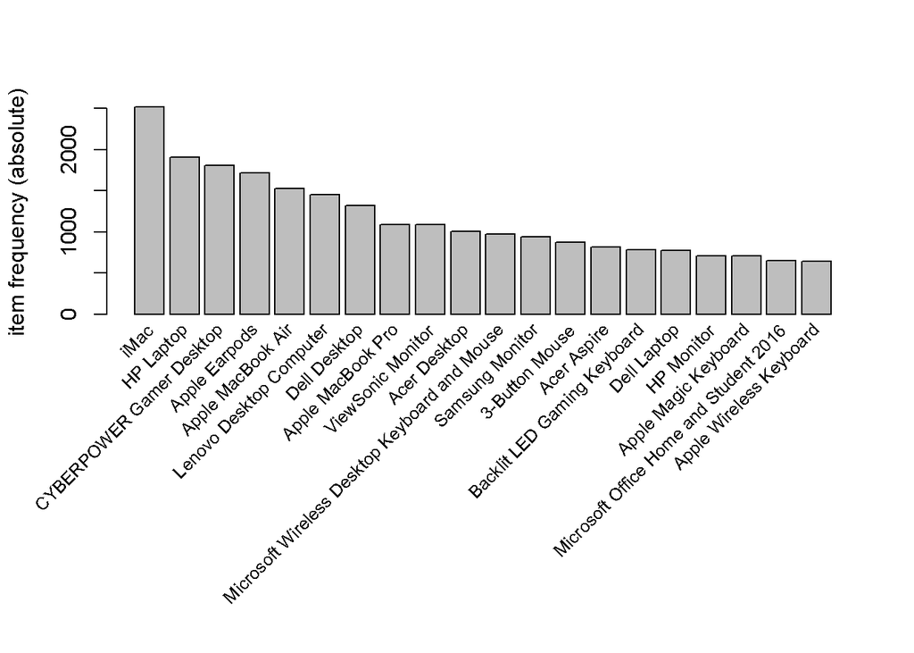

```r
# plot most frequent items
itemFrequencyPlot(df_transactions,
                  topN = 20,
                  type = 'absolute',
                  cex.names = 0.8) #reduce label size (easier reading)
```

# MINE ASSOCIATION RULES

```r
# find all potentially valuable association rules
ruleset_01 <- df_transactions %>%
  apriori(parameter = list(supp = 0.01, conf = 0.15))
```

```
## Apriori
##
## Parameter specification:
##  confidence minval smax arem  aval originalSupport maxtime
##        0.15    0.1    1 none FALSE            TRUE       5
##  support minlen maxlen target  ext
##     0.01      1     10  rules TRUE
##
## Algorithmic control:
##  filter tree heap memopt load sort verbose
##     0.1 TRUE TRUE  FALSE TRUE    2    TRUE
##
## Absolute minimum support count: 98
##
## set item appearances ...[0 item(s)] done [0.00s].
## set transactions ...[125 item(s), 9835 transaction(s)] done [0.01s].
## sorting and recoding items ... [82 item(s)] done [0.00s].
## creating transaction tree ... done [0.00s].
## checking subsets of size 1 2 3 4 done [0.00s].
## writing ... [388 rule(s)] done [0.00s].
## creating S4 object  ... done [0.00s].
```

```r
summary(ruleset_01)
```

```
## set of 388 rules
##
## rule length distribution (lhs + rhs):sizes
##   1   2   3
##   5 258 125
##
##    Min. 1st Qu.  Median    Mean 3rd Qu.    Max.
##   1.000   2.000   2.000   2.309   3.000   3.000
##
## summary of quality measures:
##     support          confidence        coverage
##  Min.   :0.01007   Min.   :0.1504   Min.   :0.01739
##  1st Qu.:0.01159   1st Qu.:0.1977   1st Qu.:0.04026
##  Median :0.01490   Median :0.2582   Median :0.05877
##  Mean   :0.02073   Mean   :0.2895   Mean   :0.08430
##  3rd Qu.:0.02232   3rd Qu.:0.3671   3rd Qu.:0.08897
##  Max.   :0.25613   Max.   :0.6023   Max.   :1.00000
##       lift            count
##  Min.   :0.7145   Min.   :  99.0
##  1st Qu.:1.3818   1st Qu.: 114.0
##  Median :1.6881   Median : 146.5
##  Mean   :1.7394   Mean   : 203.8
##  3rd Qu.:2.0597   3rd Qu.: 219.5
##  Max.   :3.3596   Max.   :2519.0
##
## mining info:
##  data ntransactions support confidence
##     .          9835    0.01       0.15
```

With support and confidence set very low, the algorithm found 388 rules. Let’s examine a subset of the rules with the highest confidence.

```r
ruleset_01 %>%
  sort(by = 'confidence') %>%
  head() %>%
  inspect()
```

```
##     lhs                          rhs            support confidence   coverage     lift count
## [1] {Acer Aspire,
##      ViewSonic Monitor}       => {HP Laptop} 0.01077783  0.6022727 0.01789527 3.102856   106
## [2] {ASUS 2 Monitor,
##      Lenovo Desktop Computer} => {iMac}      0.01087951  0.5911602 0.01840366 2.308083   107
## [3] {Apple Magic Keyboard,
##      Dell Desktop}            => {iMac}      0.01016777  0.5847953 0.01738688 2.283232   100
## [4] {ASUS Monitor,
##      HP Laptop}               => {iMac}      0.01179461  0.5829146 0.02023386 2.275889   116
## [5] {ASUS 2 Monitor,
##      HP Laptop}               => {iMac}      0.01108287  0.5828877 0.01901373 2.275784   109
## [6] {Dell Desktop,
##      ViewSonic Monitor}       => {HP Laptop} 0.01525165  0.5747126 0.02653787 2.960869   150
```

```r
# use apriori function to find association rules
ruleset_02 <- df_transactions %>%
  apriori(parameter = list(supp = 0.04, conf = 0.15))
```

```
## Apriori
##
## Parameter specification:
##  confidence minval smax arem  aval originalSupport maxtime
##        0.15    0.1    1 none FALSE            TRUE       5
##  support minlen maxlen target  ext
##     0.04      1     10  rules TRUE
##
## Algorithmic control:
##  filter tree heap memopt load sort verbose
##     0.1 TRUE TRUE  FALSE TRUE    2    TRUE
##
## Absolute minimum support count: 393
##
## set item appearances ...[0 item(s)] done [0.00s].
## set transactions ...[125 item(s), 9835 transaction(s)] done [0.00s].
## sorting and recoding items ... [32 item(s)] done [0.00s].
## creating transaction tree ... done [0.00s].
## checking subsets of size 1 2 3 done [0.00s].
## writing ... [25 rule(s)] done [0.00s].
## creating S4 object  ... done [0.00s].
```

```r
ruleset_02 %>%
  inspect() %>%
  kbl() %>%
  kable_paper('striped', 'condensed', font_size = 10)
```

```
##      lhs
## [1]  {}                         =>
## [2]  {}                         =>
## [3]  {}                         =>
## [4]  {}                         =>
## [5]  {}                         =>
## [6]  {ViewSonic Monitor}        =>
## [7]  {HP Laptop}                =>
## [8]  {ViewSonic Monitor}        =>
## [9]  {iMac}                     =>
## [10] {Apple Earpods}            =>
## [11] {iMac}                     =>
## [12] {Dell Desktop}             =>
## [13] {HP Laptop}                =>
## [14] {Dell Desktop}             =>
```

[output cut: 63 more lines]

|  | lhs |  | rhs | support | confidence | coverage | lift | count |
| --- | --- | --- | --- | --- | --- | --- | --- | --- |
| [1] | {} | => | {Apple MacBook Air} | 0.1555669 | 0.1555669 | 1.0000000 | 1.0000000 | 1530 |
| [2] | {} | => | {Apple Earpods} | 0.1743772 | 0.1743772 | 1.0000000 | 1.0000000 | 1715 |
| [3] | {} | => | {CYBERPOWER Gamer Desktop} | 0.1839349 | 0.1839349 | 1.0000000 | 1.0000000 | 1809 |
| [4] | {} | => | {HP Laptop} | 0.1941027 | 0.1941027 | 1.0000000 | 1.0000000 | 1909 |
| [5] | {} | => | {iMac} | 0.2561261 | 0.2561261 | 1.0000000 | 1.0000000 | 2519 |
| [6] | {ViewSonic Monitor} | => | {HP Laptop} | 0.0479919 | 0.4350230 | 0.1103203 | 2.2412004 | 472 |
| [7] | {HP Laptop} | => | {ViewSonic Monitor} | 0.0479919 | 0.2472499 | 0.1941027 | 2.2412004 | 472 |
| [8] | {ViewSonic Monitor} | => | {iMac} | 0.0494154 | 0.4479263 | 0.1103203 | 1.7488507 | 486 |
| [9] | {iMac} | => | {ViewSonic Monitor} | 0.0494154 | 0.1929337 | 0.2561261 | 1.7488507 | 486 |
| [10] | {Apple Earpods} | => | {iMac} | 0.0402644 | 0.2309038 | 0.1743772 | 0.9015239 | 396 |
| [11] | {iMac} | => | {Apple Earpods} | 0.0402644 | 0.1572052 | 0.2561261 | 0.9015239 | 396 |
| [12] | {Dell Desktop} | => | {HP Laptop} | 0.0449415 | 0.3353566 | 0.1340112 | 1.7277277 | 442 |
| [13] | {HP Laptop} | => | {Dell Desktop} | 0.0449415 | 0.2315348 | 0.1941027 | 1.7277277 | 442 |
| [14] | {Dell Desktop} | => | {iMac} | 0.0546009 | 0.4074355 | 0.1340112 | 1.5907615 | 537 |
| [15] | {iMac} | => | {Dell Desktop} | 0.0546009 | 0.2131798 | 0.2561261 | 1.5907615 | 537 |
| [16] | {CYBERPOWER Gamer Desktop} | => | {HP Laptop} | 0.0426029 | 0.2316197 | 0.1839349 | 1.1932842 | 419 |
| [17] | {HP Laptop} | => | {CYBERPOWER Gamer Desktop} | 0.0426029 | 0.2194866 | 0.1941027 | 1.1932842 | 419 |
| [18] | {CYBERPOWER Gamer Desktop} | => | {iMac} | 0.0567361 | 0.3084577 | 0.1839349 | 1.2043198 | 558 |
| [19] | {iMac} | => | {CYBERPOWER Gamer Desktop} | 0.0567361 | 0.2215165 | 0.2561261 | 1.2043198 | 558 |
| [20] | {Lenovo Desktop Computer} | => | {HP Laptop} | 0.0461617 | 0.3118132 | 0.1480427 | 1.6064341 | 454 |
| [21] | {HP Laptop} | => | {Lenovo Desktop Computer} | 0.0461617 | 0.2378208 | 0.1941027 | 1.6064341 | 454 |
| [22] | {Lenovo Desktop Computer} | => | {iMac} | 0.0587697 | 0.3969780 | 0.1480427 | 1.5499321 | 578 |
| [23] | {iMac} | => | {Lenovo Desktop Computer} | 0.0587697 | 0.2294561 | 0.2561261 | 1.5499321 | 578 |
| [24] | {HP Laptop} | => | {iMac} | 0.0755465 | 0.3892090 | 0.1941027 | 1.5195993 | 743 |
| [25] | {iMac} | => | {HP Laptop} | 0.0755465 | 0.2949583 | 0.2561261 | 1.5195993 | 743 |